# A10

## Logistic Regression

```
Accuracy Score: 0.891876216910394
Precision: 0.0
Recall: 0.0

              precision    recall  f1-score   support

           0       0.89      1.00      0.94    322935
           1       0.00      0.00      0.00     39150

    accuracy                           0.89    362085
   macro avg       0.45      0.50      0.47    362085
weighted avg       0.80      0.89      0.84    362085


Coeffecients of every feature:

fyear  : 2.0276388316541482e-18
annret_lag  : -4.759516226248556e-15
sigmae_lag  : 7.90283919057578e-20
exret_lag  : -3.585588622389862e-14
mktret_lag  : -3.306496077346165e-20
relative_size  : 7.964991278534224e-31
debt_face_value  : -1.0660061501027879e-11
NI/AT  : -2.4568056043187627e-20
LT/AT  : 2.94238326229018e-20
NetdebtissuedbyNetassets  : 3.2919185051373187e-20
Leverage  : -4.0450163575968943e-19
InterestBurden  : 9.647501625879359e-20
Spread  : -6.570711773200909e-20
CreditSpread  : 5.05027812263618e-20
GDPGrowth  : -7.567820031447937e-16
PIGrowth  : -8.76007727504228e-16
ActivityIndex  : 1.8252008925595935e-20
Industry_labels  : 2.444381671541003e-19
cusip_labels  : -7.749175427845646e-17
```

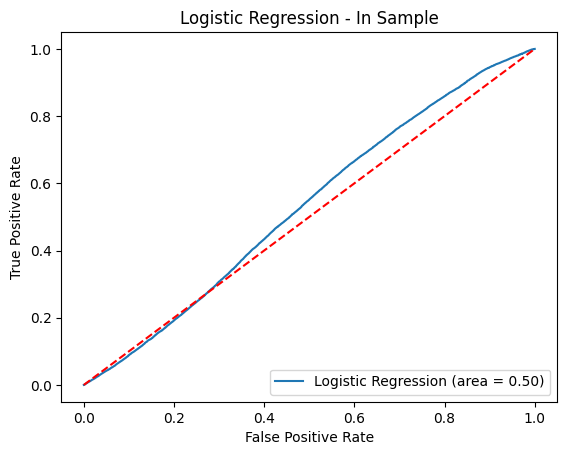

```
Axes(0.125,0.11;0.775x0.77)
```

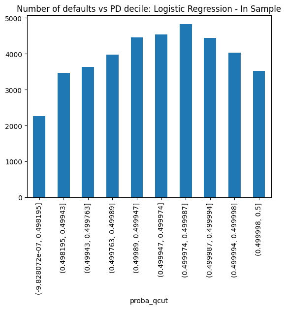

```python
X = df2[features]
y = df2[['bankruptcy_dt']]
y_pred, y_proba, coeffs = basic_logistic_regression(X,y,X)
fit_logistic_compute_metrics(X,y, y_pred, y_proba, coeffs, 'Logistic Regression - In Sample')
```

## Out of Sample Logistic Regression

```
Accuracy Score: 0.9124465788430189
Precision: 0.0
Recall: 0.0

              precision    recall  f1-score   support

           0       0.91      1.00      0.95    207098
           1       0.00      0.00      0.00     19872

    accuracy                           0.91    226970
   macro avg       0.46      0.50      0.48    226970
weighted avg       0.83      0.91      0.87    226970


Coeffecients of every feature:

fyear  : 3.511564396486708e-16
annret_lag  : -4.757124958073509e-19
sigmae_lag  : 1.767745133507996e-18
exret_lag  : 5.756660515717073e-20
mktret_lag  : -5.072898160242486e-19
relative_size  : -3.1106762695603153e-30
debt_face_value  : -1.0908758951168596e-10
NI/AT  : -7.379958285712322e-19
LT/AT  : 1.1058307465231028e-18
NetdebtissuedbyNetassets  : 1.8721306572800655e-18
Leverage  : -5.631203965468142e-18
InterestBurden  : 1.0444604748445227e-17
Spread  : 1.9327773751916107e-19
CreditSpread  : -4.7920950710514716e-20
GDPGrowth  : 1.5358585922322645e-15
PIGrowth  : 7.328915346835747e-16
ActivityIndex  : -1.5494996691316926e-20
Industry_labels  : 4.792594613454816e-18
cusip_labels  : 2.8656698188178895e-15
```

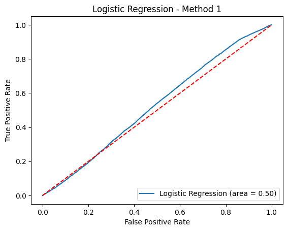

```
Axes(0.125,0.11;0.775x0.77)
```

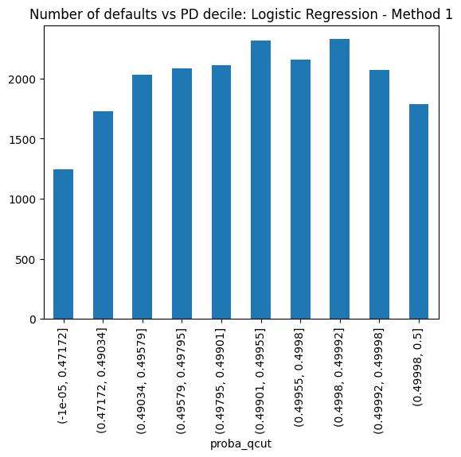

```python
X_train = df2[features][df2.fyear <= 1990]
y_train = df2[['bankruptcy_dt']][df2.fyear <= 1990]
X_test = df2[features][df2.fyear > 1990]
y_test = df2[['bankruptcy_dt']][df2.fyear > 1990]
y_pred, y_proba, coeffs = basic_logistic_regression(X_train,y_train,X_test)
fit_logistic_compute_metrics(X_test,y_test, y_pred, y_proba, coeffs, 'Logistic Regression - Method 1')
```

```
Accuracy Score: 0.9124465788430189
Precision: 0.0
Recall: 0.0

              precision    recall  f1-score   support

           0       0.91      1.00      0.95    207098
           1       0.00      0.00      0.00     19872

    accuracy                           0.91    226970
   macro avg       0.46      0.50      0.48    226970
weighted avg       0.83      0.91      0.87    226970


Coeffecients of every feature:

fyear  : 1.2041560469489362e-18
annret_lag  : -3.969920027462287e-15
sigmae_lag  : 6.329664332328014e-20
exret_lag  : -2.9901893456797263e-14
mktret_lag  : -2.829242951382039e-20
relative_size  : 6.030322157248136e-31
debt_face_value  : -9.179127817357968e-12
NI/AT  : -2.0518434494164002e-20
LT/AT  : 2.4104538617444184e-20
NetdebtissuedbyNetassets  : 2.7154733186131515e-20
Leverage  : -3.3917499425685035e-19
InterestBurden  : 7.70275604109251e-20
Spread  : -6.211141553785831e-20
CreditSpread  : 3.764851578987051e-20
GDPGrowth  : -5.619378047287916e-16
PIGrowth  : -6.406610258871114e-16
ActivityIndex  : 1.3773291345490945e-20
Industry_labels  : 1.947829100578774e-19
cusip_labels  : -6.176945272265816e-17
```

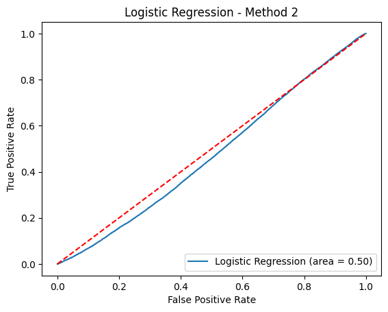

```
Axes(0.125,0.11;0.775x0.77)
```

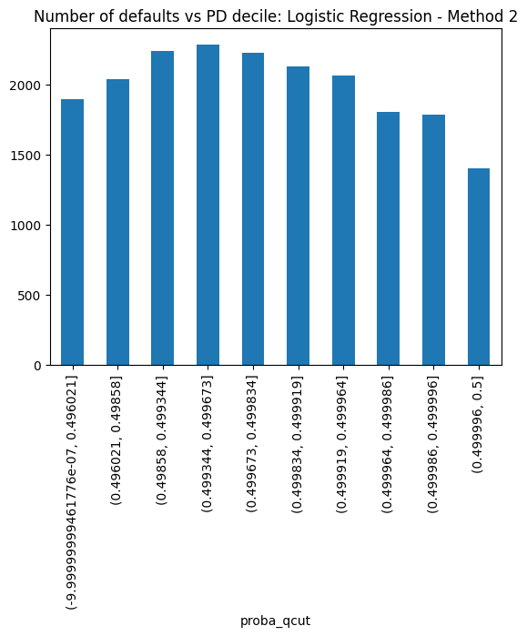

```python
y_pred_list = []
y_proba_list = []
for i in tqdm(range(1991,2020)):
    X_train = df2[features][df2.fyear < i]
    y_train = df2[['bankruptcy_dt']][df2.fyear < i]
    X_test = df2[features][df2.fyear == i]
    y_test = df2[['bankruptcy_dt']][df2.fyear == i]
    y_pred, y_proba, coeffs = basic_logistic_regression(X_train,y_train,X_test)
    y_pred_list.append(y_pred)
    y_proba_list.append(y_proba)

y_pred_list = np.concatenate(y_pred_list).ravel()
y_proba_list = np.concatenate(y_proba_list).ravel()
fit_logistic_compute_metrics(df2[features][df2.fyear >= 1991],df2[['bankruptcy_dt']][df2.fyear >= 1991], y_pred_list, y_proba_list, coeffs, 'Logistic Regression - Method 2')
```

```
Accuracy Score: 0.9124465788430189
Precision: 0.0
Recall: 0.0

              precision    recall  f1-score   support

           0       0.91      1.00      0.95    207098
           1       0.00      0.00      0.00     19872

    accuracy                           0.91    226970
   macro avg       0.46      0.50      0.48    226970
weighted avg       0.83      0.91      0.87    226970


Coeffecients of every feature:

fyear  : 3.589888766031966e-19
annret_lag  : -1.7636260912976775e-15
sigmae_lag  : 2.4258306392661125e-20
exret_lag  : -1.3278051166090451e-14
mktret_lag  : -1.0603769345912921e-20
relative_size  : 2.893482355803131e-32
debt_face_value  : -5.063664884413632e-12
NI/AT  : -8.35242413227308e-21
LT/AT  : 7.474064959629515e-21
NetdebtissuedbyNetassets  : 3.293740842184157e-21
Leverage  : -7.885861915514471e-20
InterestBurden  : -3.248006451008557e-20
Spread  : -1.5462619449907475e-20
CreditSpread  : 6.855103997986324e-21
GDPGrowth  : -1.2258202045570066e-16
PIGrowth  : -1.5949631968194519e-16
ActivityIndex  : 5.085541162266511e-21
Industry_labels  : 7.640169363965671e-20
cusip_labels  : -3.103306218951439e-17
```

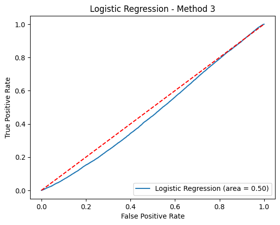

```
Axes(0.125,0.11;0.775x0.77)
```

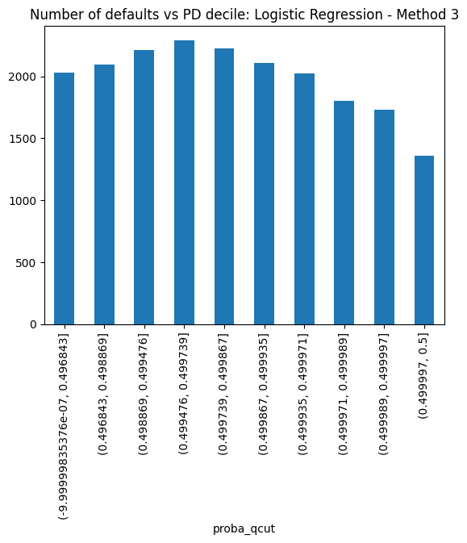

```python
y_pred_list = []
y_proba_list = []
for i in tqdm(range(1991,2020)):
    X_train = df2[features][(df2.fyear >= 1964+i-1991)&(df2.fyear < i)]
    y_train = df2[['bankruptcy_dt']][(df2.fyear >= 1964+i-1991)&(df2.fyear < i)]
    X_test = df2[features][df2.fyear == i]
    y_test = df2[['bankruptcy_dt']][df2.fyear == i]
    y_pred, y_proba, coeffs = basic_logistic_regression(X_train,y_train,X_test)
    y_pred_list.append(y_pred)
    y_proba_list.append(y_proba)

y_pred_list = np.concatenate(y_pred_list).ravel()
y_proba_list = np.concatenate(y_proba_list).ravel()
fit_logistic_compute_metrics(df2[features][df2.fyear >= 1991],df2[['bankruptcy_dt']][df2.fyear >= 1991], y_pred_list, y_proba_list, coeffs, 'Logistic Regression - Method 3')
```

## Lasso Regression

```python
X_train = df2[features][df2.fyear <= 1990]
y_train = df2[['bankruptcy_dt']][df2.fyear <= 1990]
X_test = df2[features][df2.fyear > 1990]
y_test = df2[['bankruptcy_dt']][df2.fyear > 1990]
X_train_ros, y_train_ros = RandomOverSampler(random_state=903776295).fit_resample(X_train,y_train)

sel_ = SelectFromModel(LogisticRegression(C=1, penalty="l1",solver="liblinear"))
sel_.fit(X_train_ros,y_train_ros)
sel_.get_support()

#Selecting optimal features/covariates.
X_ros_train_selected=sel_.transform(X_train_ros) #Updated training set with reduced features.
X_test_selected = sel_.transform(X_test) #Updated testing set with reduced features.

selected_feat = X_train_ros.columns[sel_.get_support()]

X_ros_train_selected = pd.DataFrame(X_ros_train_selected,columns=selected_feat)
X_test_selected = pd.DataFrame(X_test_selected,columns=selected_feat)

print("features with coefficients shrank to zero:{}".format(np.sum(sel_.get_support()==False)))

#Specifying a range of alpha values for cross-validation and fitting over the training set.
reg = LassoCV(alphas=np.array([0.001,0.01,0.1,1,0.005,0.05,0.5,5]),cv=5).fit(X_train_ros,y_train_ros)

#Regression score.
print("Accuracy: ",reg.score(X_train_ros,y_train_ros))
print("Optimized alpha(penalty) for highest score: {}".format(reg.alpha_))
```

```
features with coefficients shrank to zero:3
Accuracy:  0.0010595112395808126
Optimized alpha(penalty) for highest score: 5.0
```

```python
def Lasso_implement(X_train, y_train, X_test):
    X_train_ros, y_train_ros = RandomOverSampler(random_state=903776295).fit_resample(X_train,y_train)
    logreg = LogisticRegression(penalty='l1',C=100, solver='liblinear')
    logreg.fit(X_train_ros,y_train_ros)
    y_pred=logreg.predict(X_test)
    y_proba = logreg.predict_proba(X_test)[:,1]
    coeffs = list(logreg.coef_)
    return y_pred , y_proba, coeffs
```

```
Accuracy Score: 0.6759351456139578
Precision: 0.14528129832027173
Recall: 0.5531904186795491

              precision    recall  f1-score   support

           0       0.94      0.69      0.79    207098
           1       0.15      0.55      0.23     19872

    accuracy                           0.68    226970
   macro avg       0.54      0.62      0.51    226970
weighted avg       0.87      0.68      0.75    226970


Coeffecients of every feature:

fyear  : -0.0001911888337121089
annret_lag  : 0.11010730546499066
sigmae_lag  : 1.327385901493335
exret_lag  : 0.3430009940702683
mktret_lag  : -0.21357368879061217
relative_size  : 0.0
debt_face_value  : -8.368115420955119e-11
NI/AT  : -0.006584257263737543
LT/AT  : 0.679625628529783
NetdebtissuedbyNetassets  : 0.014208275111940507
Leverage  : -0.00043122681185692267
InterestBurden  : 0.0005184224492886666
Spread  : 0.00047497536807411886
CreditSpread  : 0.10134700821144137
GDPGrowth  : -0.0001348475724824541
PIGrowth  : 0.00011670198935573665
ActivityIndex  : -0.04109174401312774
Industry_labels  : 0.05467261630735418
cusip_labels  : 7.341112970408827e-07
```

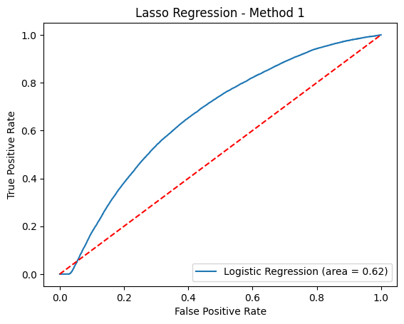

```
Axes(0.125,0.11;0.775x0.77)
```

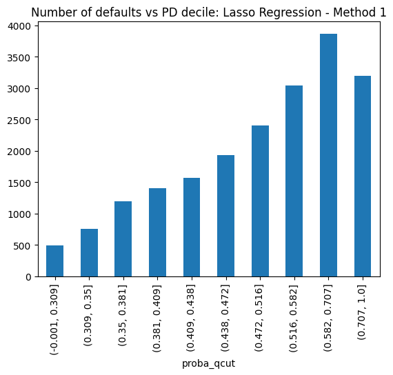

```python
X_train = df2[features][df2.fyear <= 1990]
y_train = df2[['bankruptcy_dt']][df2.fyear <= 1990]
X_test = df2[features][df2.fyear > 1990]
y_test = df2[['bankruptcy_dt']][df2.fyear > 1990]
y_pred, y_proba, coeffs = Lasso_implement(X_train,y_train,X_test)
fit_logistic_compute_metrics(X_test,y_test, y_pred, y_proba, coeffs, 'Lasso Regression - Method 1')
```

## Ridge Regression

```python
X_train = df2[features][df2.fyear <= 1990]
y_train = df2[['bankruptcy_dt']][df2.fyear <= 1990]
X_test = df2[features][df2.fyear > 1990]
y_test = df2[['bankruptcy_dt']][df2.fyear > 1990]
X_train_ros, y_train_ros = RandomOverSampler(random_state=903776295).fit_resample(X_train,y_train)
reg = RidgeCV(cv=5).fit(X_train_ros,y_train_ros)

#Regression score.
print(reg.score(X_train_ros,y_train_ros))
print("Optimized alpha(penalty) for highest score: {}".format(reg.alpha_))
```

```
0.04399963343118629
Optimized alpha(penalty) for highest score: 10.0
```

```python
def Ridge_implement(X_train, y_train, X_test):


    X_train_ros, y_train_ros = RandomOverSampler(random_state=903776295).fit_resample(X_train,y_train)


    logreg = LogisticRegression(penalty='l2',C=10, solver='liblinear')
    logreg.fit(X_train_ros,y_train_ros)
    y_pred=logreg.predict(X_test)
    y_proba = logreg.predict_proba(X_test)[:,1]
    coeffs = list(logreg.coef_)
    return y_pred , y_proba, coeffs
```

```
Accuracy Score: 0.9124465788430189
Precision: 0.0
Recall: 0.0

              precision    recall  f1-score   support

           0       0.91      1.00      0.95    207098
           1       0.00      0.00      0.00     19872

    accuracy                           0.91    226970
   macro avg       0.46      0.50      0.48    226970
weighted avg       0.83      0.91      0.87    226970


Coeffecients of every feature:

fyear  : 1.6093611426738896e-16
annret_lag  : -2.6516962176037826e-19
sigmae_lag  : 9.706650053393127e-19
exret_lag  : 2.9635312004369536e-20
mktret_lag  : -2.8031290610319856e-19
relative_size  : -1.9566693421290987e-30
debt_face_value  : -1.0907530641177254e-10
NI/AT  : -4.0810519219520115e-19
LT/AT  : 5.984856997212391e-19
NetdebtissuedbyNetassets  : 1.0343310166922265e-18
Leverage  : -3.15222013920232e-18
InterestBurden  : 5.755822183488929e-18
Spread  : 9.465532893682274e-20
CreditSpread  : -1.9200202931123725e-20
GDPGrowth  : 7.17919837254163e-16
PIGrowth  : 3.5694488131236897e-16
ActivityIndex  : -7.884989219534076e-21
Industry_labels  : 2.581013562380237e-18
cusip_labels  : 1.3516423462773608e-15
```

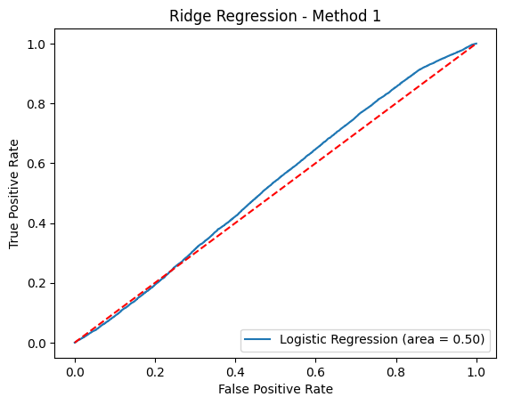

```
Axes(0.125,0.11;0.775x0.77)
```

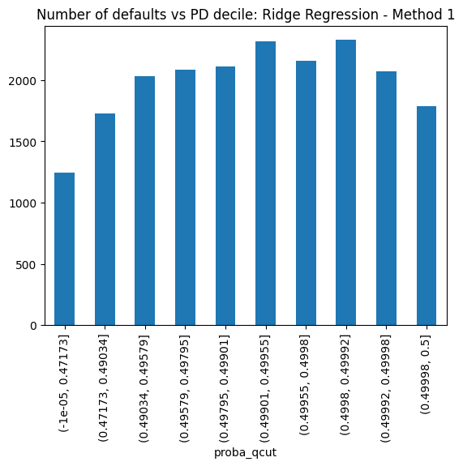

```python
X_train = df2[features][df2.fyear <= 1990]
y_train = df2[['bankruptcy_dt']][df2.fyear <= 1990]
X_test = df2[features][df2.fyear > 1990]
y_test = df2[['bankruptcy_dt']][df2.fyear > 1990]
y_pred, y_proba, coeffs = Ridge_implement(X_train,y_train,X_test)
fit_logistic_compute_metrics(X_test,y_test, y_pred, y_proba, coeffs, 'Ridge Regression - Method 1')
```

## KNN

```python
X_train = df2[features][df2.fyear <= 1990]
y_train = df2[['bankruptcy_dt']][df2.fyear <= 1990]
X_test = df2[features][df2.fyear > 1990]
y_test = df2[['bankruptcy_dt']][df2.fyear > 1990]
X_train_ros, y_train_ros = RandomOverSampler(random_state=903776295).fit_resample(X_train,y_train)

#Hyperparameter Tuning
n_neighbors = list(range(1,30))
hyperparameters = dict(n_neighbors=n_neighbors)

knn_2 = KNeighborsClassifier()

clf = GridSearchCV(knn_2, hyperparameters, cv =5)

best_model = clf.fit(X_train_ros,y_train_ros)

print('Best number of neighbours:', best_model.best_estimator_.get_params()['n_neighbors'])
```

```
Best number of neighbours: 1
```

```
Accuracy Score: 0.8086266907520818
Precision: 0.11153972964061985
Recall: 0.17023953301127215

              precision    recall  f1-score   support

           0       0.92      0.87      0.89    207098
           1       0.11      0.17      0.13     19872

    accuracy                           0.81    226970
   macro avg       0.51      0.52      0.51    226970
weighted avg       0.85      0.81      0.83    226970
```

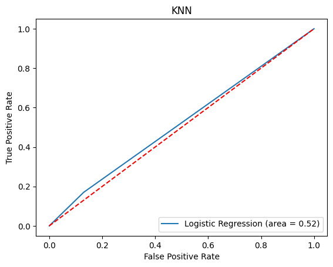

```
Axes(0.125,0.11;0.775x0.77)
```

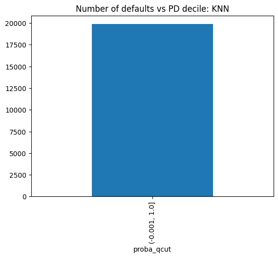

```python
knn=KNeighborsClassifier(n_neighbors=1)
knn.fit(X_train_ros, y_train_ros)
y_pred_knn =knn.predict(X_test)
fit_model_compute_metrics(X_test,y_test, y_pred_knn, knn.predict_proba(X_test)[:,1], 'KNN')
```

## Random Forrest Classifier

```
Accuracy Score: 0.9107282900823898
Precision: 0.3954983922829582
Recall: 0.03713768115942029

              precision    recall  f1-score   support

           0       0.91      0.99      0.95    207098
           1       0.40      0.04      0.07     19872

    accuracy                           0.91    226970
   macro avg       0.66      0.52      0.51    226970
weighted avg       0.87      0.91      0.88    226970
```

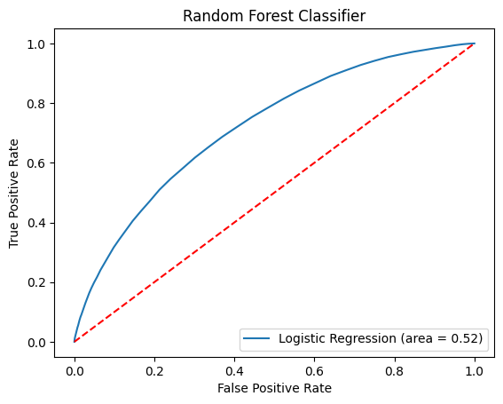

```
Axes(0.125,0.11;0.775x0.77)
```

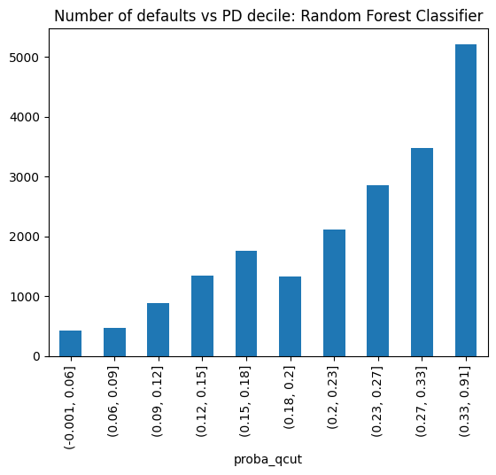

```python
rf = RandomForestClassifier(random_state=42, n_estimators =100 , max_depth = 50)
rf.fit(X_train_ros, y_train_ros)
y_pred_rf = rf.predict(X_test)
fit_model_compute_metrics(X_test,y_test, y_pred_rf, rf.predict_proba(X_test)[:,1], 'Random Forest Classifier')
```

```python
X_train = df2[features][df2.fyear <= 1990]
y_train = df2[['bankruptcy_dt']][df2.fyear <= 1990]
X_test = df2[features][df2.fyear > 1990]
y_test = df2[['bankruptcy_dt']][df2.fyear > 1990]
X_train_ros, y_train_ros = RandomOverSampler(random_state=903776295).fit_resample(X_train,y_train)
rsf = RandomSurvivalForest(random_state=42, n_estimators = 50)
rsf.fit(X_train_ros, y_train_ros)
y_pred_rsf = rsf.predict(X_test)
fit_model_compute_metrics(X_test,y_test, y_pred_rsf, rsf.predict_proba(X_test)[:,1], 'Survival Random Forest')
```

[output not shown]

## XGBOOST Classifier

```
Accuracy Score: 0.8349693792131119
Precision: 0.22141250277240898
Recall: 0.35165056360708535

              precision    recall  f1-score   support

           0       0.93      0.88      0.91    207098
           1       0.22      0.35      0.27     19872

    accuracy                           0.83    226970
   macro avg       0.58      0.62      0.59    226970
weighted avg       0.87      0.83      0.85    226970
```

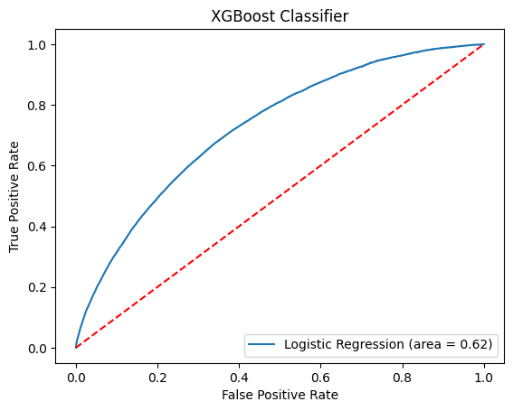

```
Axes(0.125,0.11;0.775x0.77)
```

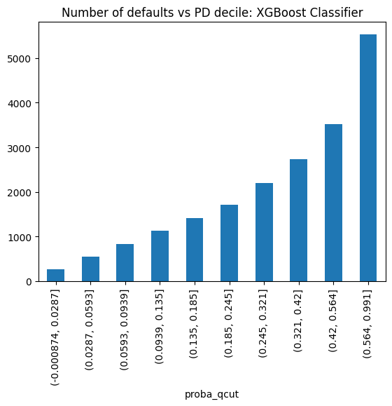

```python
X_train = df2[features][df2.fyear <= 1990]
y_train = df2[['bankruptcy_dt']][df2.fyear <= 1990]
X_test = df2[features][df2.fyear > 1990]
y_test = df2[['bankruptcy_dt']][df2.fyear > 1990]
X_train_ros, y_train_ros = RandomOverSampler(random_state=903776295).fit_resample(X_train,y_train)
xgb =XGBClassifier(n_estimators = 90)
xgb.fit(X_train_ros, y_train_ros)
y_pred_xgb = xgb.predict(X_test)
fit_model_compute_metrics(X_test,y_test, y_pred_xgb, xgb.predict_proba(X_test)[:,1], 'XGBoost Classifier')
```

## LightGBM Classifier

```
[LightGBM] [Info] Number of positive: 115837, number of negative: 115837
[LightGBM] [Info] Auto-choosing col-wise multi-threading, the overhead of testing was 0.009198 seconds.
You can set `force_col_wise=true` to remove the overhead.
[LightGBM] [Info] Total Bins 3210
[LightGBM] [Info] Number of data points in the train set: 231674, number of used features: 19
[LightGBM] [Info] [binary:BoostFromScore]: pavg=0.500000 -> initscore=0.000000
Accuracy Score: 0.7588095342996872
Precision: 0.19431246383926223
Recall: 0.5577194041867954

              precision    recall  f1-score   support

           0       0.95      0.78      0.85    207098
           1       0.19      0.56      0.29     19872

    accuracy                           0.76    226970
   macro avg       0.57      0.67      0.57    226970
weighted avg       0.88      0.76      0.81    226970
```

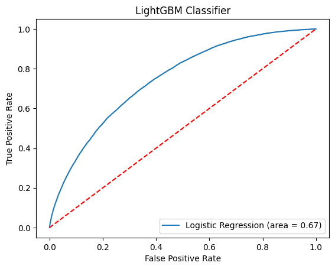

```
Axes(0.125,0.11;0.775x0.77)
```

[figure not shown]

```python
X_train = df2[features][df2.fyear <= 1990]
y_train = df2[['bankruptcy_dt']][df2.fyear <= 1990]
X_test = df2[features][df2.fyear > 1990]
y_test = df2[['bankruptcy_dt']][df2.fyear > 1990]
X_train_ros, y_train_ros = RandomOverSampler(random_state=903776295).fit_resample(X_train,y_train)
lgb = LGBMClassifier(max_depth=-1)
lgb.fit(X_train_ros, y_train_ros)
y_pred_lgb = lgb.predict(X_test)
fit_model_compute_metrics(X_test,y_test, y_pred_lgb, lgb.predict_proba(X_test)[:,1], 'LightGBM Classifier')
```

```python
import os
import json
from transformers import pipeline, AutoTokenizer, AutoModelForSequenceClassification
from concurrent.futures import ThreadPoolExecutor
import pandas as pd
from tqdm import tqdm

# Load tokenizer and model for sentiment analysis
tokenizer = AutoTokenizer.from_pretrained("ipuneetrathore/bert-base-cased-finetuned-finBERT")
model = AutoModelForSequenceClassification.from_pretrained("ipuneetrathore/bert-base-cased-finetuned-finBERT")
classifier = pipeline('sentiment-analysis', model=model, tokenizer=tokenizer, framework="pt")

def process_json_file(filepath):
    # Check if file is empty
    if os.stat(filepath).st_size == 0:
        company_id = os.path.basename(filepath).split('_')[0]
        year = os.path.basename(filepath).split('_')[1].split('.')[0]
        return [company_id, year, 0]

    try:
        with open(filepath, 'r') as file:
            data = json.load(file)
    except json.JSONDecodeError:
        # Handling JSON decode error (invalid JSON file)
        company_id = os.path.basename(filepath).split('_')[0]
        year = os.path.basename(filepath).split('_')[1].split('.')[0]
        return [company_id, year, 0]

    company_id = data.get('cik', 'Unknown')
    year = data.get('year', 'Unknown')

    sections_to_include = ['section_1', 'section_1A', 'section_1B', 'section_2', 'section_3', 'section_4',
                           'section_5', 'section_6', 'section_7', 'section_7A', 'section_8', 'section_9',
                           'section_9A', 'section_9B', 'section_10', 'section_11', 'section_12', 'section_13',
                           'section_14', 'section_15']
    text_content = " ".join([data.get(section, '') for section in sections_to_include])

    if not text_content.strip():
        return [company_id, year, 0]

    result = classifier(text_content, truncation=True)
    sentiment_score = sum([res['score'] for res in result]) / len(result) if result else 0
    return [company_id, year, sentiment_score]

# Path to the directory containing the JSON files
directory_path = './10K'

# List all JSON files in the directory
file_paths = [os.path.join(directory_path, file) for file in os.listdir(directory_path) if file.endswith('.json')]

# Use ThreadPoolExecutor to process files in parallel
with ThreadPoolExecutor(max_workers=64) as executor:
    # Wrapping file_paths with tqdm for progress tracking
    results = list(tqdm(executor.map(process_json_file, file_paths), total=len(file_paths)))

# Create DataFrame
df_sentiment = pd.DataFrame(results, columns=['company_id', 'year', 'sentiment'])
df_sentiment.to_csv("sentiment.csv")
```

## Model using Setiment Analysis

```python
se = pd.read_csv("sentiment.csv")
```

```python
# Merge df2 with the sentiment data
merged_df = df2.merge(se, left_on=['permno', 'fyear'], right_on=['company_id', 'year'])
merged_df.head()
```

|  | cusip | fyear | annret | sigmae | exret | mk_ret | mkt_cap | annret_lag | sigmae_lag | exret_lag | ... | GDPGrowth | PIGrowth | ActivityIndex | bankruptcy_dt | Industry_labels | cusip_labels | Unnamed: 0 | company_id | year | sentiment |
| --- | --- | --- | --- | --- | --- | --- | --- | --- | --- | --- | --- | --- | --- | --- | --- | --- | --- | --- | --- | --- | --- |
| 0 | 032153 | 1995 | 2.121352 | 0.663451 | 0.357150 | 1.297010 | 61037500.0 | 0.451967 | 0.641920 | -0.006291 | ... | 11319.951 | 6148.6 | 0.10 | 1 | 1 | 1705 | 3238 | 75149 | 1995 | 0.999991 |
| 1 | 25467V | 1995 | 0.515147 | 0.659547 | 0.139997 | 0.341287 | 418384750.0 | 0.487962 | 0.906051 | 0.219983 | ... | 11319.951 | 6148.6 | 0.10 | 0 | 7 | 7863 | 3765 | 81699 | 1995 | 0.000000 |
| 2 | 032153 | 1996 | -0.888888 | 0.841336 | 0.212480 | -0.908093 | 191221875.0 | 2.121352 | 0.663451 | 0.357150 | ... | 11614.418 | 6453.9 | -0.86 | 1 | 1 | 1705 | 3239 | 75149 | 1996 | 0.999991 |
| 3 | 09247Q | 1996 | 0.086101 | 0.164501 | 0.212480 | -0.111327 | 33266250.0 | 0.230498 | 0.173973 | 0.357150 | ... | 11614.418 | 6453.9 | -0.86 | 0 | 2 | 3507 | 3468 | 79326 | 1996 | 0.991533 |
| 4 | 14159K | 1996 | -0.457828 | 0.698896 | 0.077608 | -0.497359 | 238700000.0 | -0.334092 | 1.225406 | 0.201688 | ... | 11614.418 | 6453.9 | -0.86 | 0 | 3 | 4811 | 3970 | 83490 | 1996 | 0.000000 |

5 rows × 33 columns

```python
features = ['fyear','annret_lag', 'sigmae_lag', 'exret_lag', 'mktret_lag', 'relative_size',
       'debt_face_value', 'NI/AT', 'LT/AT', 'NetdebtissuedbyNetassets',
       'Leverage', 'InterestBurden', 'Spread',
       'CreditSpread', 'GDPGrowth', 'PIGrowth', 'ActivityIndex', 'Industry_labels','cusip_labels','sentiment']
```

```
Accuracy Score: 1.0
Precision: 1.0
Recall: 1.0

              precision    recall  f1-score   support

           0       1.00      1.00      1.00        47
           1       1.00      1.00      1.00         3

    accuracy                           1.00        50
   macro avg       1.00      1.00      1.00        50
weighted avg       1.00      1.00      1.00        50


Coeffecients of every feature:

fyear  : 0.0010439163738112708
annret_lag  : 4.972599950772978e-06
sigmae_lag  : 1.4596144180252862e-07
exret_lag  : 6.775211713342568e-07
mktret_lag  : 3.032711283868431e-06
relative_size  : 2.068462165313534e-18
debt_face_value  : -6.661074940733002e-05
NI/AT  : 5.333241867327056e-07
LT/AT  : 2.2676752738391626e-06
NetdebtissuedbyNetassets  : 4.956931386338867e-08
Leverage  : 1.9631472783565196e-06
InterestBurden  : 2.0648788617939798e-07
Spread  : -1.378859003557868e-06
CreditSpread  : 4.54556530299312e-07
GDPGrowth  : 0.0041061717265844936
PIGrowth  : 0.0014595425570543968
ActivityIndex  : 1.201596121337304e-06
Industry_labels  : -8.62040631326012e-06
cusip_labels  : -0.0120920420011813
sentiment  : 2.7553398442047853e-06
```

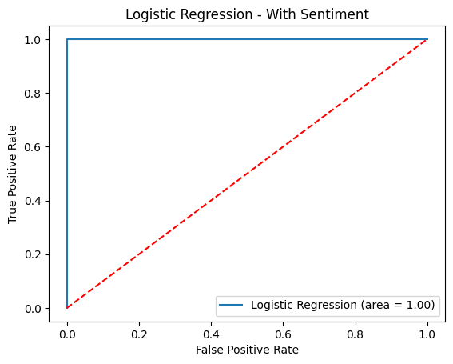

```
Axes(0.125,0.11;0.775x0.77)
```

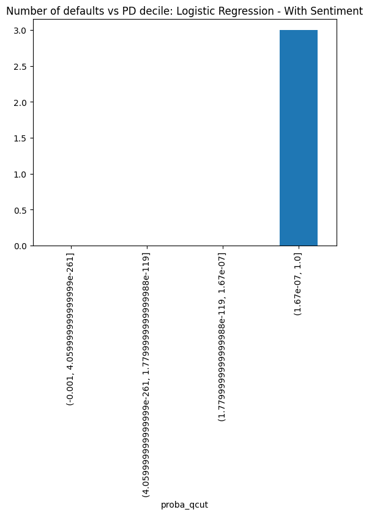

```python
X = merged_df[features]
y = merged_df[['bankruptcy_dt']]
y_pred, y_proba, coeffs = basic_logistic_regression(X,y,X)
fit_logistic_compute_metrics(X,y, y_pred, y_proba, coeffs, 'Logistic Regression - With Sentiment')
```

## Descriptive Stats

```python
import pandas as pd
import numpy as np

# Assuming df2 is your DataFrame
# Selecting numeric columns from df2
numeric_cols = df2.select_dtypes(include=[np.number]).columns

# Compute descriptive statistics for numeric columns
descriptive_stats = df2[numeric_cols].describe(percentiles=[.01, .05, .25, .50, .75, .95, .99]).T

# Adding skewness and kurtosis
descriptive_stats['skewness'] = df2[numeric_cols].skew()
descriptive_stats['kurtosis'] = df2[numeric_cols].kurtosis()

descriptive_stats
```

|  | count | mean | std | min | 1% | 5% | 25% | 50% | 75% | 95% | 99% | max | skewness | kurtosis |
| --- | --- | --- | --- | --- | --- | --- | --- | --- | --- | --- | --- | --- | --- | --- |
| fyear | 362085.0 | 1.995252e+03 | 1.437552e+01 | 1.964000e+03 | 1.965000e+03 | 1.971000e+03 | 1.984000e+03 | 1.996000e+03 | 2.007000e+03 | 2.017000e+03 | 2.019000e+03 | 2.019000e+03 | -0.192582 | -0.914500 |
| annret | 362085.0 | 2.332901e+04 | 9.866663e+05 | -1.000000e+00 | -9.565217e-01 | -7.095474e-01 | -2.222208e-01 | 5.393361e-02 | 3.597072e-01 | 1.620341e+00 | 1.611721e+02 | 6.469497e+07 | 59.289810 | 3796.121587 |
| sigmae | 362085.0 | 5.410795e-01 | 4.856108e-01 | 0.000000e+00 | 7.508937e-02 | 1.346865e-01 | 2.654459e-01 | 4.219330e-01 | 6.640783e-01 | 1.321815e+00 | 2.288806e+00 | 3.563256e+01 | 7.085144 | 184.055413 |
| exret | 362085.0 | 1.705345e+05 | 5.837931e+06 | -1.000000e+00 | -4.432568e-01 | -2.087023e-01 | -6.290601e-03 | 1.301221e-01 | 2.569700e-01 | 3.571502e-01 | 7.552421e+02 | 3.432783e+08 | 47.274433 | 2557.593048 |
| mk_ret | 362085.0 | 2.602254e-02 | 1.200005e+00 | -1.000000e+00 | -9.623445e-01 | -7.509516e-01 | -3.046360e-01 | -5.991971e-02 | 1.738372e-01 | 8.953536e-01 | 2.485837e+00 | 1.265413e+02 | 43.064898 | 3435.434606 |
| mkt_cap | 362085.0 | 1.465166e+09 | 1.016971e+10 | 0.000000e+00 | 1.076950e+06 | 3.146138e+06 | 1.954800e+07 | 8.696425e+07 | 4.285106e+08 | 4.597962e+09 | 2.544624e+10 | 8.762962e+11 | 25.612687 | 1088.749009 |
| annret_lag | 362085.0 | 9.747957e+03 | 3.477072e+05 | -1.000000e+00 | -9.440934e-01 | -6.832715e-01 | -2.133920e-01 | 5.675039e-02 | 3.354734e-01 | 1.490273e+00 | 8.123205e+01 | 1.763493e+07 | 41.215216 | 1816.042122 |
| sigmae_lag | 362085.0 | 5.257581e-01 | 4.091717e-01 | 0.000000e+00 | 8.538459e-02 | 1.419091e-01 | 2.710036e-01 | 4.266514e-01 | 6.618204e-01 | 1.229069e+00 | 1.927998e+00 | 2.313445e+01 | 5.741596 | 136.241848 |
| exret_lag | 362085.0 | 7.335357e+04 | 2.727657e+06 | -1.000000e+00 | -4.858945e-01 | -2.087023e-01 | -6.290601e-03 | 1.269758e-01 | 2.440128e-01 | 3.571502e-01 | 1.994569e+02 | 1.463005e+08 | 42.852429 | 1988.656987 |
| mktret_lag | 362085.0 | 2.577069e-02 | 1.135303e+00 | -1.000000e+00 | -9.475124e-01 | -7.122677e-01 | -2.910214e-01 | -5.768813e-02 | 1.603253e-01 | 8.556198e-01 | 2.485447e+00 | 1.265413e+02 | 39.346821 | 3015.026775 |
| relative_size | 362085.0 | 6.673488e-12 | 8.428229e-12 | 3.056430e-13 | 4.680827e-13 | 5.769086e-13 | 1.088690e-12 | 2.359943e-12 | 8.980336e-12 | 2.566762e-11 | 3.483690e-11 | 5.187637e-11 | 0.000000 | 0.000000 |
| debt_face_value | 362085.0 | 7.589800e+08 | 1.125304e+10 | 5.000000e+02 | 3.050000e+04 | 2.500000e+05 | 3.226000e+06 | 1.996200e+07 | 1.362715e+08 | 1.675631e+09 | 8.729000e+09 | 1.677174e+12 | 45.147781 | 3138.978691 |
| NI/AT | 362085.0 | -6.366158e-02 | 2.728156e+00 | -1.501250e+03 | -1.480928e+00 | -5.035340e-01 | -2.071892e-02 | 2.152765e-02 | 6.152934e-02 | 1.346200e-01 | 2.287931e-01 | 2.310345e+01 | -477.481763 | 256031.368773 |
| LT/AT | 362085.0 | 5.973678e-01 | 2.458285e+00 | 3.737829e-05 | 8.879853e-02 | 1.819421e-01 | 3.904564e-01 | 5.625000e-01 | 7.527740e-01 | 9.497115e-01 | 1.468746e+00 | 1.410500e+03 | 525.606082 | 299200.671537 |
| NetdebtissuedbyNetassets | 362085.0 | 2.387558e-02 | 2.220570e+00 | -4.182105e+02 | -5.440180e-01 | -1.523064e-01 | -2.021956e-02 | 0.000000e+00 | 4.590216e-02 | 2.729740e-01 | 6.598983e-01 | 7.544750e+02 | 127.243058 | 45909.428986 |
| Leverage | 362085.0 | 4.661628e+00 | 1.323673e+02 | -1.112817e+04 | -1.385267e+01 | 6.864532e-01 | 1.673599e+00 | 2.309588e+00 | 3.749625e+00 | 1.238589e+01 | 3.488662e+01 | 2.958600e+04 | 186.441706 | 41773.236382 |
| InterestBurden | 362085.0 | 7.458013e-01 | 2.675358e+01 | -5.102300e+03 | -4.142081e+00 | -2.376052e-01 | 6.525810e-01 | 8.875314e-01 | 1.000000e+00 | 1.723677e+00 | 5.616938e+00 | 1.095400e+04 | 165.672462 | 83370.909040 |
| permno | 362085.0 | 5.795575e+04 | 2.792141e+04 | 1.000000e+04 | 1.030400e+04 | 1.165200e+04 | 3.168300e+04 | 6.530700e+04 | 8.268900e+04 | 9.132600e+04 | 9.292800e+04 | 9.343600e+04 | -0.410194 | -1.326412 |
| Spread | 362085.0 | 1.136486e+00 | 1.184874e+00 | -1.640000e+00 | -1.640000e+00 | -4.400000e-01 | 1.500000e-01 | 1.230000e+00 | 1.870000e+00 | 3.070000e+00 | 3.400000e+00 | 3.400000e+00 | -0.061002 | -0.578311 |
| CreditSpread | 362085.0 | -7.015238e-01 | 5.683578e-01 | -2.990000e+00 | -2.990000e+00 | -1.490000e+00 | -9.800000e-01 | -7.600000e-01 | 0.000000e+00 | 0.000000e+00 | 0.000000e+00 | 0.000000e+00 | -1.022744 | 3.010344 |
| ThreeMonthYield | 362085.0 | 4.456307e+00 | 3.181646e+00 | 2.000000e-02 | 2.000000e-02 | 7.000000e-02 | 1.710000e+00 | 4.940000e+00 | 6.140000e+00 | 9.410000e+00 | 1.465000e+01 | 1.465000e+01 | 0.592451 | 0.494537 |
| GDPGrowth | 362085.0 | 1.215427e+04 | 4.545416e+03 | 4.135553e+03 | 4.362111e+03 | 5.443619e+03 | 8.034847e+03 | 1.161442e+04 | 1.635383e+04 | 1.939834e+04 | 2.041515e+04 | 2.041515e+04 | 0.101837 | -1.196111 |
| PIGrowth | 362085.0 | 7.443602e+03 | 4.959857e+03 | 5.113000e+02 | 5.515000e+02 | 8.988000e+02 | 3.140700e+03 | 6.453900e+03 | 1.164710e+04 | 1.629330e+04 | 1.805390e+04 | 1.805390e+04 | 0.438656 | -0.921439 |
| ActivityIndex | 362085.0 | -1.142844e-01 | 7.328906e-01 | -2.960000e+00 | -2.960000e+00 | -1.320000e+00 | -2.900000e-01 | 0.000000e+00 | 2.100000e-01 | 1.090000e+00 | 1.390000e+00 | 1.390000e+00 | -1.108260 | 3.426478 |
| bankruptcy_dt | 362085.0 | 1.081238e-01 | 3.105371e-01 | 0.000000e+00 | 0.000000e+00 | 0.000000e+00 | 0.000000e+00 | 0.000000e+00 | 0.000000e+00 | 1.000000e+00 | 1.000000e+00 | 1.000000e+00 | 2.523875 | 4.369968 |
| Industry_labels | 362085.0 | 4.021183e+00 | 2.231564e+00 | 0.000000e+00 | 1.000000e+00 | 2.000000e+00 | 2.000000e+00 | 3.000000e+00 | 6.000000e+00 | 8.000000e+00 | 9.000000e+00 | 9.000000e+00 | 0.842800 | -0.732739 |
| cusip_labels | 362085.0 | 1.459755e+04 | 8.343100e+03 | 0.000000e+00 | 2.730000e+02 | 1.483000e+03 | 7.453000e+03 | 1.445900e+04 | 2.183100e+04 | 2.760100e+04 | 2.884900e+04 | 2.919300e+04 | -0.010463 | -1.176783 |

## Addig Text Based Features

- Improved Contextual Understanding: Text-based features can provide additional context that numeric data alone may not capture, such as management's outlook or market sentiment. This can enhance the model's ability to predict events like bankruptcies, which are often influenced by qualitative factors.
- Beneficial for Sentiment Analysis: Text from financial reports or news articles can be analyzed for sentiment, which can be a valuable predictor of a company's financial health. Positive sentiment might indicate good financial health, while negative sentiment could be a warning sign of potential problems.
- Useful in Identifying Trends and Anomalies: Text analysis can help identify emerging trends or anomalies in a company's reporting or in media coverage that may not be immediately apparent from quantitative data.
- Conditions for Benefit:
  - Quality and Relevance of Text Data: The added text data should be relevant to the prediction task. For example, management discussion and analysis (MD&A) sections from annual reports are likely to be more relevant for bankruptcy prediction than unrelated news articles.
  - Sophisticated Natural Language Processing (NLP) Techniques: Effective text analysis requires advanced NLP techniques to accurately extract sentiment, themes, and other relevant information from text.
  - Integration with Quantitative Data: The text-based features should complement the existing quantitative data, providing a more holistic view of the company's situation.
  - Avoidance of Overfitting: Care must be taken to ensure that the model doesn't overfit the text data, which can be very high-dimensional and noisy.
  - Timely and Consistent Data Availability: The text data used should be consistently available for all companies in the dataset and timely enough to be relevant for the prediction task.

In summary, adding text-based features to a model predicting company bankruptcies can be highly beneficial under conditions where the text data is relevant, high-quality, and analyzed using appropriate NLP techniques. It can provide a richer, more nuanced view of a company's health and prospects than quantitative data alone.